# TP Statistique

Mathieu Richelmy, Arthur Tondereau, Yoan Simiad–Cossin

31 mars 2020

# 0. Visualisation de chemins

On commence par prendre en main l’environnement de travail, les package et données fournis pour le calcul de plus courts chemins.

```
## 'data.frame':    22 obs. of  5 variables:
##  $ EU_circo : Factor w/ 7 levels "ÃŽle-de-France",..: 6 6 4 3 7 4 3 2 3 4 ...
##  $ region   : Factor w/ 22 levels "Alsace","Aquitaine",..: 22 10 19 11 2 5 9 3 6 17 ...
##  $ ville    : Factor w/ 22 levels "Ajaccio","Amiens",..: 11 1 2 3 4 5 6 7 8 9 ...
##  $ latitude : num  45.7 41.9 49.9 47.2 44.8 ...
##  $ longitude: num  4.847 8.733 2.3 6.033 -0.567 ...
```

Représentation des chemins par plus proches voisins et du chemin optimal :

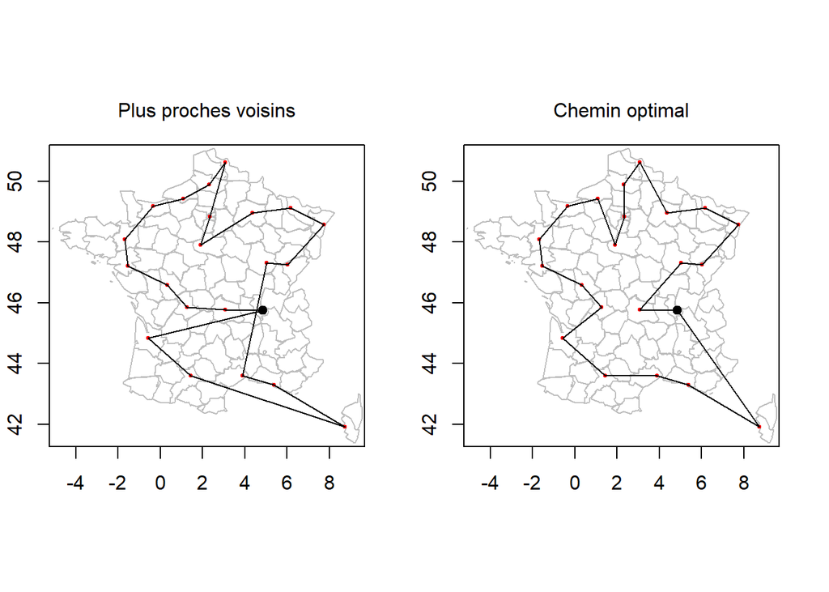

```r
coord <- cbind(villes$longitude,villes$latitude)
dist <- distanceGPS(coord)
voisins <- TSPnearest(dist)

pathOpt <- c(1,8,9,4,21,13,7,10,3,17,16,20,6,19,15,18,11,5,22,14,12,2)

par(mfrow=c(1,2),mar=c(1,1,2,1))
plotTrace(coord[voisins$chemin,], title='Plus proches voisins')
plotTrace(coord[pathOpt,], title='Chemin optimal')
```

Les longueurs des trajets (à vol d’oiseau) valent respectivement, pour la méthode des plus proches voisins :

```
## [1] 4303.568
```

et pour la méthode optimale :

```
## [1] 3793.06
```

Ceci illustre bien l’intérêt d’un algorithme de voyageur de commerce. Nous allons dans la suite étudier les performances de cet algorithme.

# 1. Comparaison d’algorithmes

Dans cette partie nous allons comparer la méthode Branch&Bound (aussi appelée “branch” par la suite) utilisée lors du TP de AAIA avec d’autres méthodes similaires :

- “repetitive_nn”, disponible dans le paquet TSP de R
- “nearest_insertion”, disponible dans le paquet TSP de R
- “two_opt”, également disponible dans le paquet TSP de R
- “nearest”, ou la méthode des “plus proches voisins”, issue du TP de AAIA

Afin de les comparer, nous allons réaliser des mesures sur des graphes de 10 sommets (n = 10), dont les coordonnées cartésiennes sont des lois uniformes sur [0,1].

Le code nous permettant de générer ces graphes est le suivant :

```r
      n <- 10
sommets <- data.frame(x = runif(n), y = runif(n))
  couts <- distance(sommets)
```

## 1.1. Longueur des chemins

Dans un premier temps, nous allons nous intéresser à la longueur des chemins obtenus à l’aide de ces différentes méthodes. Nous allons donc comparer les différents résultats obtenus à l’aide d’outils statistiques.

- Boîtes à moustaches (ou boxplots)

  Le code utilisé pour générer les boîtes à moustache (boxplots) des longueurs des chemins hamiltoniens, obtenus à l’aide des différentes méthodes et sur 50 réalisations, est le suivant :

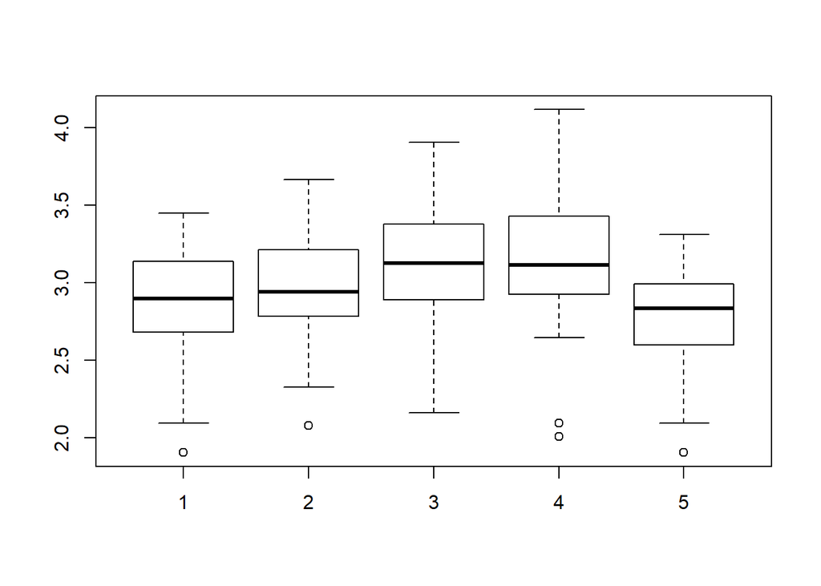

[output not shown]

```r
  n <- 10
  nbTest <- 50

  methods <- c("repetitive_nn", "nearest_insertion", "two_opt", "nearest", "branch")
  result  <- list()
  lconfig <- vector("list", n)

  for(numConfig in 1:nbTest) {
    lconfig[[numConfig]] <- data.frame(x = runif(n), y = runif(n))
  }

  for (metId in 1:5){
    met     <- methods[metId]
    dataMet <- vector("logical",n)

    for(numConfig in 1:nbTest) {
      cost               <- distance(lconfig[[numConfig]])
      dataMet[numConfig] <- TSPsolve(cost,met)
    }

    result[[metId]] <- dataMet
  }

  boxplot(result)
```

- Comparaison des algorithmes des plus proches voisins et de Branch&Bound

  On va maintenant comparer les algorithmes des plus proches voisins et de Branch&Bound entre eux. Pour se faire, nous allons réaliser un test d’hypothèses paramétriques (étant donné que les longueurs obtenues suivent une loi normale).

  Soit m<sub>nn</sub> et m<sub>b</sub> les espérances respectives des algorithmes des plus proches voisins et de Branch&Bound. Les hypothèses de notre test vont être :
  - (H<sub>0</sub>) -> m<sub>nn</sub> - m<sub>b</sub> <= 0
  - (H<sub>1</sub>) -> m<sub>nn</sub> - m<sub>b</sub> > 0

  On va donc calculer la p-value associée à ce test afin de savoir si l’on rejette l’hypothèse H<sub>0</sub>.

  Le code utilisé pour réaliser ce test est le suivant (avec result[[4]] les longueurs obtenues par l’algorithme des plus proches voisins et result[[5]] celles obtenues par l’algorithme de Branch&Bound) :

```r
  t.test(result[[4]], result[[5]], mu=0, paired=TRUE, alternative='greater')
```

```
##
##  Paired t-test
##
## data:  result[[4]] and result[[5]]
## t = 10.244, df = 49, p-value = 4.499e-14
## alternative hypothesis: true difference in means is greater than 0
## 95 percent confidence interval:
##  0.3138095       Inf
## sample estimates:
## mean of the differences
##               0.3752207
```

[output not shown]

- Comparaison 2 à 2 des longueurs moyennes obtenues par les algorithmes

  Maintenant, on va comparer les longueurs moyennes obtenues entre elles, 2 à 2. Pour se faire, nous allons tester les hypothèses suivantes (avec i != j) :
  - (H<sub>0</sub>) -> m<sub>i</sub> = m<sub>j</sub>
  - (H<sub>1</sub>) -> m<sub>i</sub> != m<sub>j</sub>

  Le code utilisé pour réaliser ces tests est le suivant :

```r
  getValuesTest <- function(methods, nbSommet, nbRep) {
    n       <- nbSommet
    nbTest  <- nbRep
    result  <-list()
    lconfig <- vector("list",n)

    for(numConfig in 1:nbTest) {
      lconfig[[numConfig]] <- data.frame(x = runif(n), y = runif(n))
    }

    for (metId in 1:5) {
      met     <-methods[metId]
      dataMet <- vector("logical",n)

      for(numConfig in 1:nbTest) {
        cost               <- distance(lconfig[[numConfig]])
        dataMet[numConfig] <- TSPsolve(cost,met)
      }

      result[[metId]] <- dataMet
    }

    return(result)
  }

  nbSommet     <- 10
  nbTest       <-50

  methods      <- c("repetitive_nn","nearest_insertion","two_opt","nearest","branch")
  res          <- getValuesTest(methods,nbSommet,nbTest)
  methodsPlain <- c(rep("repetitive_nn", nbTest),rep("nearest_insertion", nbTest),rep("two_opt", nbTest),rep("nearest", nbTest),rep("branch", nbTest))
  pairwise.t.test(unlist(res),methodsPlain,adjust.method='bonferroni')
```

[output not shown]

[output not shown]

## 1.2. Temps de calcul

Dans un second temps, nous allons comparer les temps de calcul des différents algorithmes à l’aide du package microbenchmark. Nous effecturons ces comparaisons sur 20 graphes de 10 sommets, dont les coordonnées sont des lois uniformes sur [0,1].

La fonction microbenchmark (grâce au package multcomp) va comparer les temps d’exécution des algorithmes 2 à 2 en réalisant le test ayant les hypothèses suivantes (où m représente l’espérance en temps, avec un risque alpha = 5%) :

- (H<sub>0</sub>) -> m<sub>i</sub> = m<sub>j</sub>
- (H<sub>1</sub>) -> m<sub>i</sub> != m<sub>j</sub>

Elle va ensuite attribuer des lettres (‘a’ pour les algorithmes les plus rapides et ainsi de suite), et va attribuer la même lettre à deux algorithmes si l’hypothèse H<sub>0</sub> n’est pas rejetée (donc si m<sub>i</sub> = m<sub>j</sub>).

Le code exécuté pour ces comparaisons est le suivant :

```r
  n      <- 10
  nbTest <- 20

  microbenchmark(
    TSPsolve(couts, "repetitive_nn"),
    TSPsolve(couts, "nearest_insertion"),
    TSPsolve(couts, "two_opt"),
    TSPsolve(couts, "nearest"),
    TSPsolve(couts, "branch"),
    times=nbTest,
    setup={
      sommets <- data.frame(x = runif(n), y = runif(n))
      couts <- distance(sommets)
  })
```

| expr | time |
| --- | --- |
| TSPsolve(couts, "branch") | 1101000 |
| TSPsolve(couts, "branch") | 1959700 |
| TSPsolve(couts, "nearest_insertion") | 790000 |
| TSPsolve(couts, "nearest") | 12400 |
| TSPsolve(couts, "two_opt") | 422500 |
| TSPsolve(couts, "repetitive_nn") | 4799000 |
| TSPsolve(couts, "nearest") | 16200 |
| TSPsolve(couts, "branch") | 3433600 |
| TSPsolve(couts, "repetitive_nn") | 4577100 |
| TSPsolve(couts, "repetitive_nn") | 6459300 |

[output cut: 90 more lines]

# Etude de la complexité de l’algorithme Branch&Bound

## 2.1. Comportement par rapport au nombre de sommets : premier modèle

Récupération du temps sur 10 graphes pour différentes valeurs de $n$.

```r
library("microbenchmark")
seqn <- seq(4,20,1)
nLignes <- length(seqn)
n_rep <- 10
temps <- matrix(0,nrow=nLignes,ncol=n_rep)
for (i in 1:nLignes){
   temps[i,]<- microbenchmark(TSPsolve(couts, method = 'branch'),
    times = n_rep,
    setup = {
      n <- seqn[i]
      couts <- distance(cbind(x = runif(n), y = runif(n)))}
    )$time
}
```

Visualisation de *temps* en fonction de *n*, puis de *$\log(temps)^2$* en fonction de *n* :

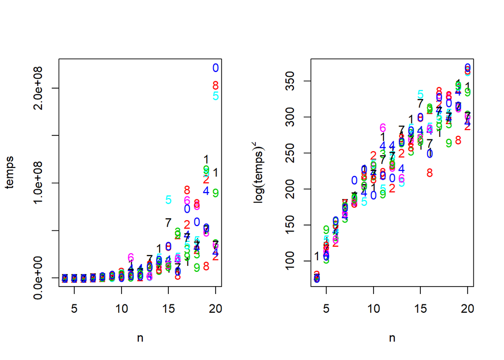

Sur ces deux graphiques, nous pouvons observer le comportement exponentielle de *temps* en fonction de *n*, c’est pourquoi le modèle de *$\log(temps)^2$* en fonction de *n* justifie une régression linéaire.

Ajustement du modèle linéaire de *$\log(temps)^2$* en fonction de *$n$*: Ci-dessous le resultat de $summary(temps.lm)$ :

```
##
## Call:
## lm(formula = vect_temps ~ vect_dim)
##
## Residuals:
##     Min      1Q  Median      3Q     Max
## -66.720 -16.749   4.176  16.666  66.524
##
## Coefficients:
##             Estimate Std. Error t value Pr(>|t|)
## (Intercept)   63.815      5.068   12.59   <2e-16 ***
## vect_dim      14.150      0.391   36.19   <2e-16 ***
## ---
## Signif. codes:  0 '***' 0.001 '**' 0.01 '*' 0.05 '.' 0.1 ' ' 1
##
## Residual standard error: 24.98 on 168 degrees of freedom
## Multiple R-squared:  0.8863, Adjusted R-squared:  0.8856
## F-statistic:  1310 on 1 and 168 DF,  p-value: < 2.2e-16
```

Nous cherchons à analyser le comportement linéaire entre les deux variables. En récupérant le $R^2$, nous obtenons 0.8863011 , ce qui est relativement faible. Néanmoins, cela reste cohérent avec le graphique observé précedement, qui ne suivait pas un alignement exact.

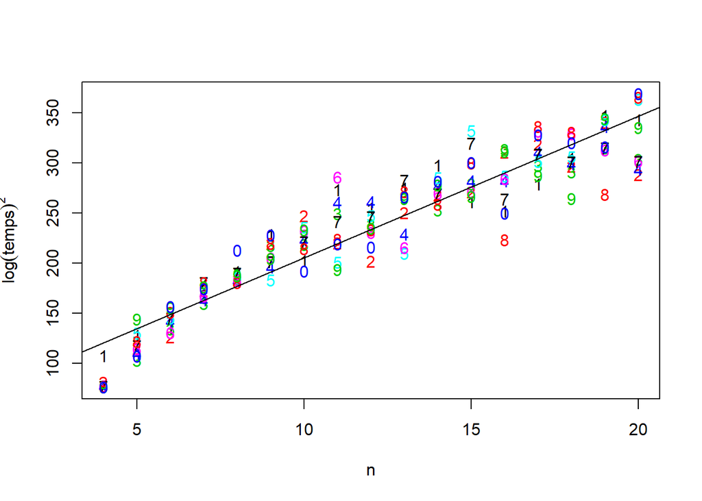

En ajoutant la droite de régression linéaire à la réprésentation des points (ligne noire), elle semble correspondre mais avec un large intervalle de prédiction.

Analyse de la validité du modèle :

Etude des hypothèses sur les résidus:

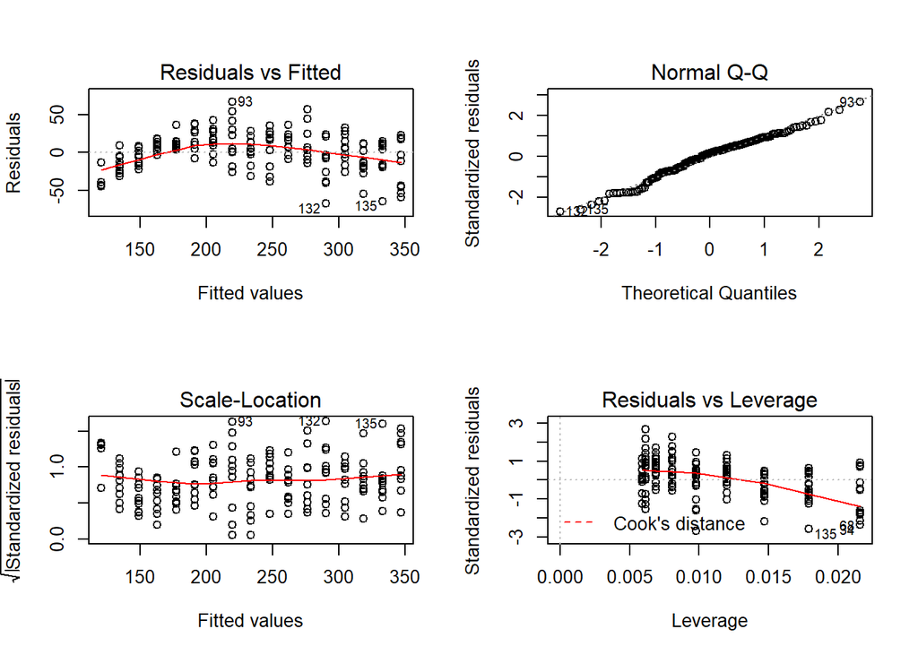

- Sur le 1er graphique, l’homogénéité de la variance n’est vérifiée, puisque les points sont répartis selon les abcisses (plusieurs lignes verticales qui se distinguent).
- Sur le 2nd graphique, on a des points proches de la ligne, on valide donc l’hypothèse d’avoir des données isssues d’une loi gaussienne.

On peut conclure que le modèle n’est pas juste. Pour étudier chaque cas plus précisément, il faudrait séparer les cas de la matrice *temps*, ou les regrouper sous une même valeur, pour réduire les degé de liberté.

Pour vérifier si les résidus suivent une loi normale, nous faisons le test de Shapiro-Wilk :

```
##
##  Shapiro-Wilk normality test
##
## data:  residuals(temps.lm)
## W = 0.98244, p-value = 0.0303
```

Nous obtenons une p-value inférieure à 5% , l’hypothèse est donc invalidée.

## 2.2. Comportement par rapport au nombre de sommets : étude du comportement moyen

Récupération du temps moyen et tracer des courbes à étudier :

```r
temps.moy <- rowMeans(temps)
vect_temps_moy <- log(as.vector(temps.moy))^2
vect_dim <- seqn
temps.moy_lm <- lm(vect_temps_moy~vect_dim)
summary(temps.moy_lm)
```

```
##
## Call:
## lm(formula = vect_temps_moy ~ vect_dim)
##
## Residuals:
##     Min      1Q  Median      3Q     Max
## -38.786 -10.777   3.099   9.969  25.263
##
## Coefficients:
##             Estimate Std. Error t value Pr(>|t|)
## (Intercept)  64.1191    10.8203   5.926 2.78e-05 ***
## vect_dim     14.5413     0.8348  17.419 2.31e-11 ***
## ---
## Signif. codes:  0 '***' 0.001 '**' 0.01 '*' 0.05 '.' 0.1 ' ' 1
##
## Residual standard error: 16.86 on 15 degrees of freedom
## Multiple R-squared:  0.9529, Adjusted R-squared:  0.9498
## F-statistic: 303.4 on 1 and 15 DF,  p-value: 2.313e-11
```

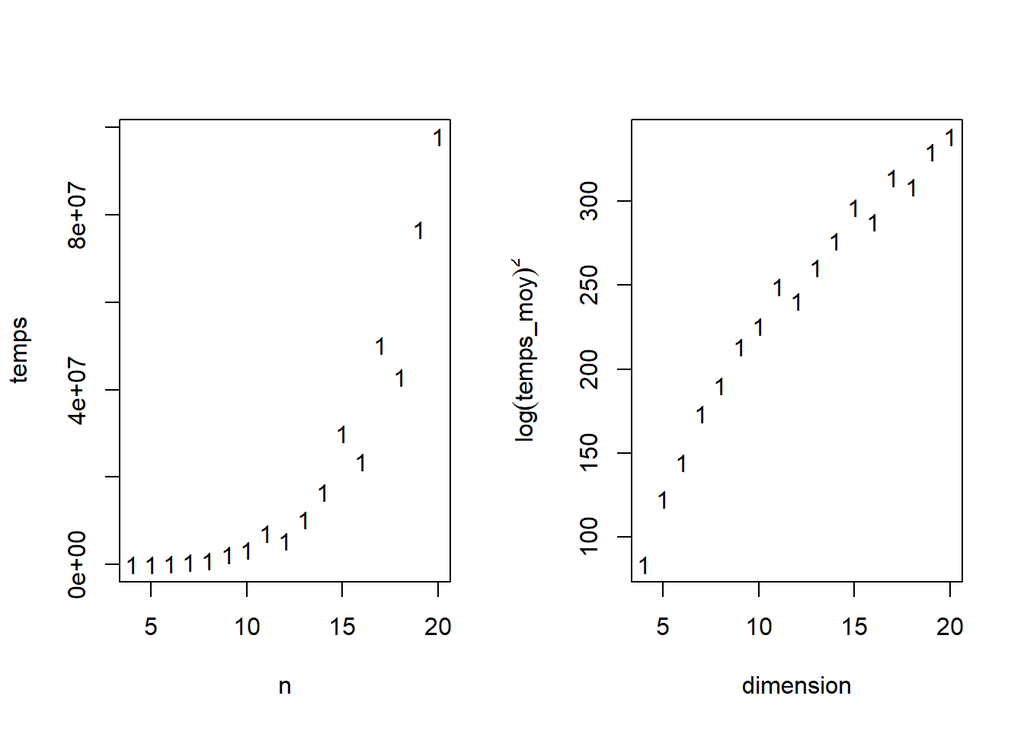

```r
par(mfrow=c(1,2)) # 2 graphiques sur 1 ligne
matplot(vect_dim, temps.moy, xlab='n', ylab='temps')
matplot(vect_dim, vect_temps_moy, xlab='dimension', ylab=expression(log(temps_moy)^2))
```

En tracant le graphe *temps_moyen* en fonction de *n*, nous observons une tendance exponentielle. Ainsi comme dans la partie 1, en traçant la courbe $\log(temps.moy)^2$ en fonction de $n$, nous voyons qu’un modèle linéaire pourrait s’y prêter, d’où la régression linéaire *temps.moy_lm*. < Analyse de la validité du modèle :

Etude des hypothèses sur les résidus.

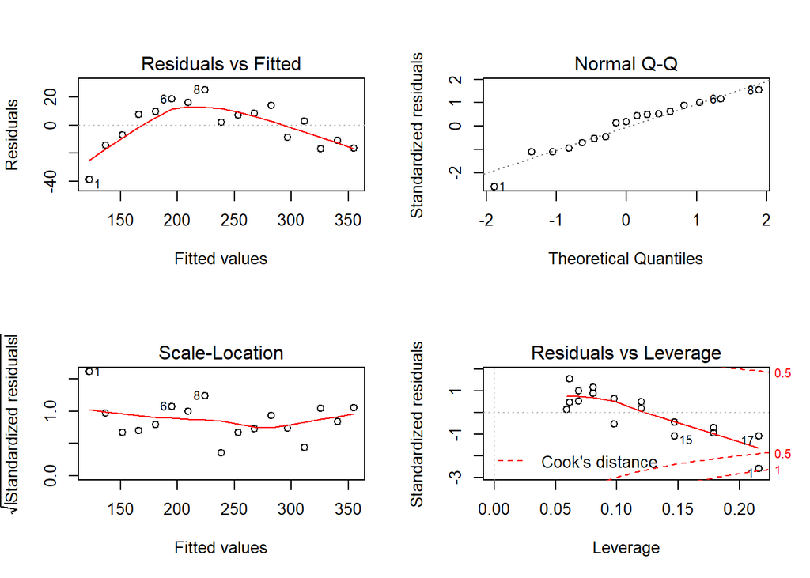

```r
par(mfrow=c(2,2)) # 4 graphiques, sur 2 lignes et 2 colonnes
plot(temps.moy_lm)
```

```
##
##  Shapiro-Wilk normality test
##
## data:  residuals(temps.moy_lm)
## W = 0.95471, p-value = 0.5351
```

Nous en tirons une p-value supérieure à 5% ainsi nous validons l’hypothèse que les résidus suivent une loi gaussienne.

## 2.3. Comportement par rapport à la structure du graphe

Nous allons ici utiliser des graphes pré construits pour étudier l’execution de l’algorithme avec différentes topologies de graphes.

Les modèles linéaires appris dans cette partie peuvent difficilement être montrés graphiquement, puisque ce sont des fonctions qui prennent un nombre de dimensions relativement élevé en entrée. On est loin de considérations big data mais une fonction avec 5-6 dimensions en entrée ne peut déjà pas bien se representer en 2D…

### Ajustement du modèle linéaire de $\log(temps.moy)$ en fonction de toutes les variables présentes.

Nous effectuons la regression linéaire attendue et obtenons comme resultats le modèle ci dessous:

```r
data.graph <- data.frame(read.csv('DonneesTSP.csv'))
data_temps <- log(data.graph$tps)
data.graph$dim <- sqrt(data.graph$dim)
data.graph$tps <- NULL
data_temps.lm <-lm(data_temps~.,data = data.graph)
coef(data_temps.lm)
```

```
##  (Intercept)          dim    mean.long    mean.dist      sd.dist     mean.deg
##  6.490342604  3.419171895 -4.815296154 -0.002004845  0.004810512 -0.136736942
##       sd.deg     diameter
##  0.139951533 -0.064681566
```

On remarque que certaines dimensions ont un rôle plus dominant que d’autres. En particulier et assez logiquement la dimension du graphe et la longueur moyenne des chemins ont une grosse influence sur le résultat.

On peut chercher à interpréter le modèle pour ces variables : plus la dimension est grande et plus le temps de calcul est long, mais la moyenne de la longueur des chemins est relativement grande alors la fonction de bound de l’algorithme aura plus de facilité à élaguer l’espace de recherche et le temps de calcul se réduit. Cette deuxième interprétation est toutefois hasardeuse compte tenu de l’erreur importante sur cette dimension. On peut étudier les propriétés de ce modèle :

```r
summary(data_temps.lm)
```

```
##
## Call:
## lm(formula = data_temps ~ ., data = data.graph)
##
## Residuals:
##      Min       1Q   Median       3Q      Max
## -0.78776 -0.15715  0.01542  0.17260  0.65036
##
## Coefficients:
##               Estimate Std. Error t value Pr(>|t|)
## (Intercept)  6.4903426  0.5450715  11.907  < 2e-16 ***
## dim          3.4191719  0.2391476  14.297  < 2e-16 ***
## mean.long   -4.8152962  0.7294055  -6.602 1.05e-08 ***
## mean.dist   -0.0020048  0.0010633  -1.886  0.06404 .
## sd.dist      0.0048105  0.0006652   7.231 8.55e-10 ***
## mean.deg    -0.1367369  0.0425459  -3.214  0.00208 **
## sd.deg       0.1399515  0.0872430   1.604  0.11376
## diameter    -0.0646816  0.1566329  -0.413  0.68107
## ---
## Signif. codes:  0 '***' 0.001 '**' 0.01 '*' 0.05 '.' 0.1 ' ' 1
##
## Residual standard error: 0.2912 on 62 degrees of freedom
## Multiple R-squared:  0.986,  Adjusted R-squared:  0.9844
## F-statistic: 622.6 on 7 and 62 DF,  p-value: < 2.2e-16
```

```r
shapiro.test(residuals(data_temps.lm))
```

```
##
##  Shapiro-Wilk normality test
##
## data:  residuals(data_temps.lm)
## W = 0.98289, p-value = 0.455
```

On utilise ici le log au carré du temps pour la série que l’on essaie de prédire, en étudiant si l’utilisation d’un modèle linéaire est plus appropriée que précédemment.

```
##
## Call:
## lm(formula = data_temps ~ ., data = data.graph)
##
## Residuals:
##      Min       1Q   Median       3Q      Max
## -12.9871  -4.1024  -0.7592   3.8924  16.5325
##
## Coefficients:
##               Estimate Std. Error t value Pr(>|t|)
## (Intercept)  -21.99890   12.40630  -1.773  0.08111 .
## dim           99.48307    5.44321  18.277  < 2e-16 ***
## mean.long   -115.41373   16.60190  -6.952  2.6e-09 ***
## mean.dist     -0.03167    0.02420  -1.309  0.19542
## sd.dist        0.11386    0.01514   7.520  2.7e-10 ***
## mean.deg      -3.43437    0.96838  -3.547  0.00075 ***
## sd.deg         4.91473    1.98573   2.475  0.01607 *
## diameter      -8.17018    3.56510  -2.292  0.02533 *
## ---
## Signif. codes:  0 '***' 0.001 '**' 0.01 '*' 0.05 '.' 0.1 ' ' 1
##
## Residual standard error: 6.627 on 62 degrees of freedom
## Multiple R-squared:  0.9916, Adjusted R-squared:  0.9906
## F-statistic:  1040 on 7 and 62 DF,  p-value: < 2.2e-16
```

```r
shapiro.test(residuals(data_temps.lm))
```

```
##
##  Shapiro-Wilk normality test
##
## data:  residuals(data_temps.lm)
## W = 0.98154, p-value = 0.3906
```

### Mise en uvre d’une sélection de variables pour ne garder que les variables pertinentes.

On peut opérer une sélection des variables pour réduire la dimension de l’entrée du modèle et augmenter son explicabilité.

On évolue à partir du modèle linéaire prenant le log du temps au carré. On va ici utiliser la fonction step qui permet de faire cette réduction de manière automatique.

```r
new_lm <-step(data_temps.lm)
```

```
## Start:  AIC=272.28
## data_temps ~ dim + mean.long + mean.dist + sd.dist + mean.deg +
##     sd.deg + diameter
##
##             Df Sum of Sq     RSS    AIC
## - mean.dist  1      75.2  2798.5 272.18
## <none>                    2723.2 272.28
## - diameter   1     230.7  2953.9 275.97
## - sd.deg     1     269.1  2992.3 276.87
## - mean.deg   1     552.5  3275.7 283.21
## - mean.long  1    2122.7  4846.0 310.62
## - sd.dist    1    2483.9  5207.2 315.65
## - dim        1   14671.8 17395.0 400.08
##
## Step:  AIC=272.18
## data_temps ~ dim + mean.long + sd.dist + mean.deg + sd.deg +
##     diameter
##
##             Df Sum of Sq   RSS    AIC
## <none>                    2798 272.18
## - sd.deg     1       299  3098 277.29
## - mean.deg   1       714  3512 286.08
## - diameter   1       718  3516 286.17
## - mean.long  1      2068  4867 308.92
## - sd.dist    1      3116  5914 322.56
## - dim        1     44208 47007 467.67
```

On voit ici que l’indicateur AIC a légèrement diminué, et que nous avons éliminé la dimension mean.dist de l’entrée. C’est une dimension sur laquelle le coefficient était très faible, c’est donc normal qu’elle soit éliminée en prioritée.

### Analyse de la validité du modèle :

- pertinence des coefficients et du modèle,

- étude des hypothèses sur les résidus

Avec les modèles déduits des données on voit que les tests de Shapiro-Wilk permettent de supposer la répartition normale des résiduts des modèles. On a dans chaque cas des p-valeur élevées ( > 35% ), on ne peut donc pas conclure que les résiduts ne sont pas répartis selon une loi normale. Cela montre que nos modèles sont bien construits.